# Absolute Pitch Recognition and the Frequency Following Response

# Comparing the Predictive Power of the FFRs to the Three Stimuli

We fit a Lasso regression model on each stimulus (with the regularization parameter $\lambda$ chosen to minimize $k$-folds cross validation loss on the training set), and then validate the model on a test set. This procedure is repeated many times, calculating $r = \text{corr}(\hat{y}, y)$ on each repetition. The $r$ values are then compared to chance performance $H_0: r = 0$ and to $r$ from models trained on the other stimuli.

```r
library(glmnet)
library(car)
```

```r
library(ggplot2)


empLogit <- function(x, eps = 1e-3) log((eps + x)/(1 - x+eps))
invLogit <- function(l, eps = 1e-3) (exp(l) + eps*exp(l) - eps)/(1 + exp(l))

cross_validation <- function(x, y) { # performs one trial of cross validation procedure
  # logit transform y so accuracy isn't [0, 1] bounded
  y <- empLogit(y)
  mu <- mean(y)
  s <- sd(y)
  y <- (y - mu)/s
  # randomly split into training and test set
  train <- sample(1:nrow(x), nrow(x)/3)
  test <- -train
  # grid search for regularization param, testing values on folds of training data
  grid <- 10^seq(10, -2, length = 100)
  lasso.fit <- glmnet(x[train,], y[train], alpha = 1, lambda = grid)
  n <- length(y[train])
  cv.out <- cv.glmnet(x[train,], y[train], alpha = 1, nfolds = n)
  # test model with optimal param on hold-out data
  predictions <- predict(lasso.fit, s = cv.out$lambda.min, newx = x[test,])
  predictions <- invLogit(predictions*s + mu)
  y_test <- invLogit(y[test]*s + mu)
  r <- cor(predictions, y_test) # return correlation b/w predictions and test vals
  return(r)
}

get_coeffs <- function(x, y) {
  y <- empLogit(y)
  mu <- mean(y)
  s <- sd(y)
  y <- (y - mu)/s
  grid <- 10^seq(10, -2, length = 100)
  lasso.fit <- glmnet(x, y, alpha = 1, lambda = grid)
  cv.out <- cv.glmnet(x, y, alpha = 1, nfolds = length(y))
  lasso.coef <- predict(lasso.fit, type = "coefficients", s = cv.out$lambda.min)
  return(lasso.coef)
}

get_preds <- function(x, y, groups) {
  y <- empLogit(y)
  mu <- mean(y)
  s <- sd(y)
  y <- (y - mu)/s
  grid <- 10^seq(10, -2, length = 100)
  lasso.fit <- glmnet(x, y, alpha = 1, lambda = grid)
  cv.out <- cv.glmnet(x, y, alpha = 1, nfolds = length(y))
  predictions <- predict(lasso.fit, s = cv.out$lambda.min, newx = x)
  yhat <- invLogit(predictions*s + mu)
  y <- invLogit(y*s + mu)
  df <- data.frame(y, yhat, groups)
  colnames(df) <- c('observed', 'predicted', 'groups')
  p <- ggplot(df, aes(x=observed, y=predicted, color = groups)) + geom_point() +
    geom_abline(intercept = 0, slope = 1, linetype="dashed") +
    xlim(0, 1) + ylim(0, 1) + coord_fixed() + theme(legend.position = "none")
  return(p)
}
```

```r
# load data
x_piano <- read.csv("data/harmonics/piano_harmonics.csv", header = FALSE) # bad subjects already removed
colnames(x_piano) <- paste('H', 0:(ncol(x_piano) - 1), sep = "")
x_complex <- read.csv("data/harmonics/complex_harmonics.csv", header = FALSE)
colnames(x_complex) <- paste('H', 0:(ncol(x_complex) - 1), sep = "")
x_da <- read.csv("data/harmonics/da_harmonics.csv", header = FALSE)
colnames(x_da) <- paste('H', 0:(ncol(x_da) - 1), sep = "")
behav <- read.csv("data/AP_FFR_Behavioral.csv") # bad subjects already removed


# remove subjects with no pitch scores
x_piano <- x_piano[!is.na(behav$AP_Piano_ACC) & !is.na(behav$Pitch.Adjustment) & behav$Group != 'NO',]
x_complex <- x_complex[!is.na(behav$AP_Piano_ACC) & !is.na(behav$Pitch.Adjustment) & behav$Group != 'NO',]
x_da <- x_da[!is.na(behav$AP_Piano_ACC) & !is.na(behav$Pitch.Adjustment) & behav$Group != 'NO',]
behav <- behav[!is.na(behav$AP_Piano_ACC) & !is.na(behav$Pitch.Adjustment) & behav$Group != 'NO',]


# put things in order for glmnet (must be in matrix format)
x_piano <- scale(as.matrix(x_piano))
x_complex <- scale(as.matrix(x_complex))
x_da <- scale(as.matrix(x_da))
y_piano <- behav$AP_Piano_Conservative
y_sine <- behav$AP_Sine_Conservative
y_avg <- (36*y_piano + 40*y_sine)/(36+40)
#y_behav <- behav["AgeOnset_instrument","JND", "Pitch.Adjustment"]
jnd <- behav$JND
pitchAdjustment <- behav$Pitch.Adjustment
tonal <- behav$Tonal
ageOnset <- behav$AgeOnset_instrument
x_behav <- data.frame(jnd, pitchAdjustment, ageOnset)
x_behav <- scale(as.matrix(x_behav)) # normalize everything but tonal
x_behav <- cbind(x_behav, tonal) # then add in tonal dummy variable
```

```r
iters <- 1000 # number of times to perform cross validation
r_piano <- 1:iters # placeholder array
r_complex <- 1:iters
r_da <- 1:iters
for (iter in 1:iters) {
  r_piano[iter] <- cross_validation(x_piano, y_avg)
  r_complex[iter] <- cross_validation(x_complex, y_avg)
  r_da[iter] <- cross_validation(x_da, y_avg)
}

# compile all r values into one dataframe for plotting
r_piano <- data.frame(r_piano)
colnames(r_piano) <- c("r")
r_piano$stimulus <- "piano tone"
r_complex <- data.frame(r_complex)
colnames(r_complex) <- c("r")
r_complex$stimulus <- "complex tone"
r_da <- data.frame(r_da)
colnames(r_da) <- c("r")
r_da$stimulus <- "speech: /da/"
r_vals <- rbind(r_piano, r_complex, r_da)

# apply Fisher z-transformation to correlation values
r_vals$z <- (log(1 + r_vals$r) - log(1 - r_vals$r)) / 2
```

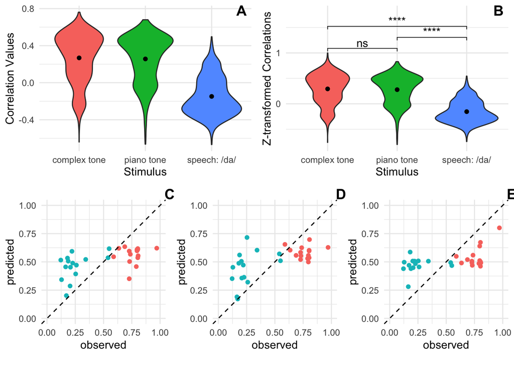

```r
library(ggplot2)
library(ggpubr)
library(gridExtra)
library(cowplot)
p1 <- ggplot(r_vals, aes(x = stimulus, y = r, fill = stimulus)) +
  geom_violin() + stat_summary(fun = mean, geom = "point") +
  theme_minimal() + guides(fill = FALSE) +
  labs(x = "Stimulus", y = "Correlation Values") #+ ylim(c(-1.2, 1.2))
comparisons = list(c(1, 2), c(2, 3), c(1, 3))
p2 <- ggplot(r_vals, aes(x = stimulus, y = z, fill = stimulus)) +
  geom_violin() + stat_summary(fun = mean, geom = "point") +
  stat_compare_means(method = "t.test", label =  "p.signif", comparisons=comparisons, paired = F) +
  theme_minimal() + guides(fill = FALSE) +
  labs(x = "Stimulus", y = "Z-transformed Correlations") + ylim(c(-.8, 1.8))
p3 <- get_preds(x_complex, y_avg, behav$Group)
p4 <- get_preds(x_piano, y_avg, behav$Group)
p5 <- get_preds(x_da, y_avg, behav$Group)
g1 <- ggarrange(p1, p2,
                ncol = 2, nrow = 1, labels = c("A", "B"), label.x = .9)
g2 <- ggarrange(p3, p4, p5,
                ncol = 3, nrow = 1,
                labels = c("C", "D", "E"), label.x = .93)
ggarrange(g1, g2, ncol = 1, nrow = 2)
```

```r
get_coeffs(x_complex, y_avg)
```

```
## 8 x 1 sparse Matrix of class "dgCMatrix"
##                         1
## (Intercept)  6.690522e-18
## H0          -3.292858e-01
## H1           .
## H2           .
## H3           .
## H4           .
## H5           1.743151e-02
## H6           .
```

```r
get_coeffs(x_piano, y_avg)
```

```
## 6 x 1 sparse Matrix of class "dgCMatrix"
##                         1
## (Intercept) -5.062962e-18
## H0          -6.311119e-02
## H1          -4.512237e-01
## H2           .
## H3           .
## H4           2.801559e-01
```

```r
get_coeffs(x_da, y_avg)
```

```
## 15 x 1 sparse Matrix of class "dgCMatrix"
##                         1
## (Intercept)  1.913053e-17
## H0           1.548811e-01
## H1           .
## H2           .
## H3           .
## H4           .
## H5           .
## H6          -2.091592e-01
## H7           .
## H8           .
## H9           .
## H10          .
## H11          .
## H12          2.170198e-01
## H13          .
```

```r
# compute t-stats to spit out in-line
p_vs_z <- t.test(r_vals$z[r_vals$stimulus == "piano tone"])
c_vs_z <- t.test(r_vals$z[r_vals$stimulus == "complex tone"])
d_vs_z <- t.test(r_vals$z[r_vals$stimulus == "speech: /da/"])
p_vs_c <- t.test(r_vals$z[r_vals$stimulus == "piano tone"], r_vals$z[r_vals$stimulus == "complex tone"])
p_vs_d <- t.test(r_vals$z[r_vals$stimulus == "piano tone"], r_vals$z[r_vals$stimulus == "speech: /da/"])
c_vs_d <- t.test(r_vals$z[r_vals$stimulus == "complex tone"], r_vals$z[r_vals$stimulus == "speech: /da/"])
pm <- mean(r_vals$r[r_vals$stimulus == "piano tone"])
cm <- mean(r_vals$r[r_vals$stimulus == "complex tone"])
dm <- mean(r_vals$r[r_vals$stimulus == "speech: /da/"])
```

The FFR to the piano tone ($r$ = 0.26, $t$(999) = 31.49, $p$ = 9.18e-152) and the FFR to the unfamiliar complex tone ($r$ = 0.27, $t$(999) = 31.91, $p$ = 1.31e-154) both predict pitch-labelling performance better than chance, but not significantly differently from one another ($t$(1994.81) = -1.19, $p$ = 2.34e-01). Both the piano tone FFR ($t$(1875.59) = 38.81, $p$ = 2.42e-242) and complex tone FFR ($t$(1840.56) = 39.16) perform significantly better than the speech-evoked FFR ($r$ = -0.15), which performs significantly worse than chance ($t$(999) = -22.71, $p$ = 2.29e-92).

# Does Piano Tone predict AP performance for piano tones more than for sine tones?

```r
r_pianoacc <- 1:iters # placeholder array
r_sineacc <- 1:iters
for (iter in 1:iters) {
  r_pianoacc[iter] <- cross_validation(x_piano, y_piano)
  r_sineacc[iter] <- cross_validation(x_piano, y_sine)
}

# compile all r values into one dataframe for plotting
r_pianoacc <- data.frame(r_pianoacc)
colnames(r_pianoacc) <- c("r")
r_pianoacc$stimulus <- "piano tones"
r_sineacc <- data.frame(r_sineacc)
colnames(r_sineacc) <- c("r")
r_sineacc$stimulus <- "sine tones"
r_vals_type <- rbind(r_pianoacc, r_sineacc)


# apply Fisher z-transformation to correlation values
r_vals_type$z <- (log(1 + r_vals_type$r) - log(1 - r_vals_type$r)) / 2
```

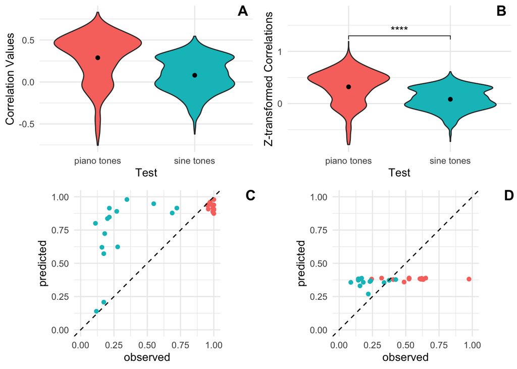

```r
p1 <- ggplot(r_vals_type, aes(x = stimulus, y = r, fill = stimulus)) +
  geom_violin() + stat_summary(fun = mean, geom = "point") +
  theme_minimal() + guides(fill = FALSE) +
  labs(x = "Test", y = "Correlation Values")
comparisons = list(c(1, 2))
p2 <- ggplot(r_vals_type, aes(x = stimulus, y = z, fill = stimulus)) +
  geom_violin() + stat_summary(fun = mean, geom = "point") +
  stat_compare_means(method = "t.test", label =  "p.signif", comparisons=comparisons, paired = F) +
  theme_minimal() + guides(fill = FALSE) +
  labs(x = "Test", y = "Z-transformed Correlations") + ylim(c(-.8, 1.75))
p3 <- get_preds(x_piano, y_piano, behav$Group)
p4 <- get_preds(x_piano, y_sine, behav$Group)
g1 <- ggarrange(p1, p2,
                ncol = 2, nrow = 1, labels = c("A", "B"), label.x = .9)
g2 <- ggarrange(p3, p4,
                ncol = 2, nrow = 1,
                labels = c("C", "D"), label.x = .93)
ggarrange(g1, g2, ncol = 1, nrow = 2)
```

```r
get_coeffs(x_piano, y_piano)
```

```
## 6 x 1 sparse Matrix of class "dgCMatrix"
##                         1
## (Intercept)  3.282769e-17
## H0          -1.322548e-02
## H1          -4.602532e-01
## H2           .
## H3          -4.402488e-03
## H4           2.476013e-01
```

```r
get_coeffs(x_piano, y_sine)
```

```
## 6 x 1 sparse Matrix of class "dgCMatrix"
##                         1
## (Intercept)  4.381401e-17
## H0           .
## H1          -8.887191e-02
## H2           .
## H3           .
## H4           1.169600e-03
```

```r
yp_vs_z <- t.test(r_vals_type$z[r_vals_type$stimulus == "piano tones"])
ys_vs_z <- t.test(r_vals_type$z[r_vals_type$stimulus == "sine tones"])
yp_vs_ys <- t.test(r_vals_type$z[r_vals_type$stimulus == "piano tones"],
                   r_vals_type$z[r_vals_type$stimulus == "sine tones"])
ypm <- mean(r_vals_type$r[r_vals_type$stimulus == "piano tones"])
ysm <- mean(r_vals_type$r[r_vals_type$stimulus == "sine tones"])
```

The piano tone FFR predicts subject performance both on piano tones ($r$ = 0.29, $t$(999) = 31.11, $p$ = 4.11e-149) and on sine tones ($r$ = 0.08, $t$(999) = 12.26, $p$ = 2.69e-32). However, the model does predict significantly better on piano tone performance ($t$(1729.47) = 19.22, $p$ = 8.70e-75), suggesting a more specific effect of auditory encoding on pitch classification ability.